# 第12回 発展 脳の画像を、区画に分ける

NIfTI・マスク・Ward法（Abrahamほか2014）

## 医用画像にも、同じパイプライン

- 読み込み → 前処理 → 次元の扱い → クラスタリング
- 脳のfMRI（脳の活動の時間変化を撮るMRI）を、区画に分ける

## Abrahamほか（2014）

- Frontiers in Neuroinformatics「Machine learning for neuroimaging with scikit-learn」
- 論文のコードは古い道具で書かれていて、今は動かない
- 同じ手順を、今の道具で書き直した版で再現する

## NIfTIという形式

- 脳の画像はNIfTI（`.nii.gz`）という医用画像の形式
- 縦×横×高さ×時間の、4次元の配列

## 1人分を、取ってくる

```python
!pip install -q nilearn
from nilearn import datasets, plotting
from nilearn.maskers import NiftiMasker
import nibabel as nib

adhd = datasets.fetch_adhd(n_subjects=1)        # 1人分を取ってくる
img = nib.load(adhd.func[0])                    # NIfTI を読む
print(img.shape)                                # 縦・横・高さ・時間
```

## 176回撮った、立体

```
(61, 73, 61, 176)
```

- 61×73×61の立体（1つの画素は3mm角）を、2秒ごとに176回

## マスクして、表にする

```python
# 脳の中だけを取り出し（マスク）、少しぼかし、場所ごとに標準化する
masker = NiftiMasker(mask_strategy='epi', smoothing_fwhm=6,
                     standardize='zscore_sample')
X = masker.fit_transform(img)                   # 時間 × 脳の場所
print(X.shape)
```

## 前処理の3段

- マスク：脳の外（頭の外の空気など）を除く
- ぼかし：となりの場所と少し平均して、ノイズを減らす
- 標準化：場所ごとに、時間の動きを平均0・標準偏差1に

## 176 × 62,546の表

```
(176, 62546)
```

- 1列が、脳の1か所（ボクセル）の、時間の動き

## 区画に分ける

```python
from sklearn.feature_extraction.image import grid_to_graph
from sklearn.cluster import FeatureAgglomeration

mask = masker.mask_img_.get_fdata().astype(bool)
conn = grid_to_graph(*mask.shape, mask=mask)    # となり合う場所だけをつなぐ
ward = FeatureAgglomeration(n_clusters=100, connectivity=conn,
                            linkage='ward').fit(X)
labels = masker.inverse_transform(ward.labels_ + 1)   # 脳の形に戻す
plotting.plot_roi(labels, title='Ward 法で100の区画',
                  display_mode='xz', cut_coords=(0, 0))
plotting.show()
```

## 列を、まとめる

- `FeatureAgglomeration`：列（場所）をまとめる版の階層クラスタリング
- つなぎ方はウォード法（第11回の課題と同じ）

## となり合う所だけを、つなぐ

- `grid_to_graph`：脳の中でとなり合う場所どうしだけを結ぶ
- `connectivity`に渡すと、となり合う所しかつながない

## Ward法で、100の区画

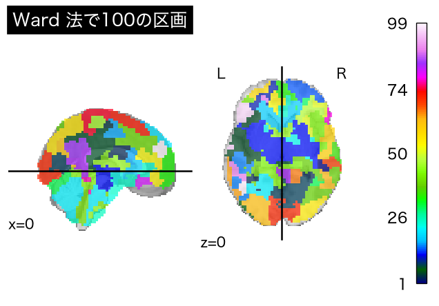

- どの区画も、ひとつながりの塊

## つながりの条件なしなら

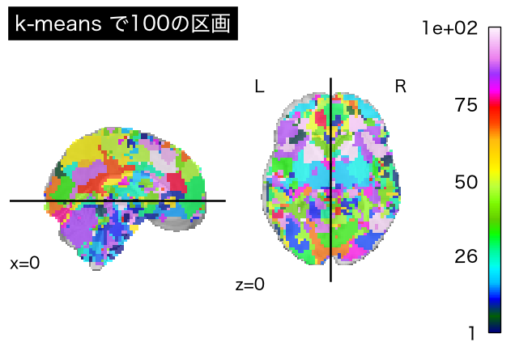

- k-meansは場所のつながりを知らないので、区画がばらばらに散らばる

## 論文の最後の図

- 論文でも、Ward法とk-meansで区画を作り、比べている
- 「となり合う所だけをつなぐ」という条件が、脳の区画らしさをつくる

## 試すなら

- `n_clusters`を20や500に変えて、区画の細かさを比べる
- 別の人（`n_subjects=2`）でも、似た区画になるか？